# R Notebook

```r
library(stringr)
library(httr)
library(purrr)
library(tidyr)
library(dplyr)
library(magrittr)
library(ggplot2)
library(knitr)
```

# Part 1

Getting access to “The Movie DB”

```r
highest_gross_drama_2010 <-str_glue("https://api.themoviedb.org/3/",
                                    "discover/movie",
                                    "?api_key=55b3238346b11e88d118b5a647963747",
                                    "&with_genres=18&primary_release_year=2010&sort_by=revenue.desc") %>%
  GET () %>%
  content () %>%
  pluck("results") %>%
  purrr::map_df(magrittr::extract,c ("title")) %>%
  kable()


actors_together<- str_glue("https://api.themoviedb.org/3/",
                           "discover/movie",
                           "?api_key=55b3238346b11e88d118b5a647963747",
                           "&with_cast=23659&with_cast=3896&sort_by=popularity.desc") %>%
  GET() %>%
  content() %>%
  pluck("results") %>%
  #map(pluck,"title") %>%
  purrr::map_df(magrittr::extract,c ("title")) %>%
  kable()
  #map_df(extract, c("title"))  Not sure why map_df does not work

tom_cruise_kidsmovies<- str_glue("https://api.themoviedb.org/3/",
                                 "discover/movie",
                                 "?api_key=55b3238346b11e88d118b5a647963747",
                                 "&certification.lte=G&with_cast=500") %>%
  GET() %>%
  content() %>%
  pluck("results") %>%
  purrr::map_df(magrittr::extract,c ("title")) %>%
  kable()
# map_df(extract, c("title"))
```

The highest grossing dramas from 2010 are :

| title |
| --- |
| Room in Rome |
| The Twilight Saga: Eclipse |
| Shutter Island |
| Three Steps Above Heaven |
| The Karate Kid |
| Flipped |
| Love & Other Drugs |
| The Social Network |
| The Town |
| El Infierno |
| Unthinkable |
| Black Swan |
| Dear John |
| Incendies |
| Sex and the City 2 |
| Chinese Grandma |
| Faster |
| 127 Hours |
| Due Date |
| Robin Hood |

Movie with actors Ferrell and Liam Neeson are :

| title |
| --- |
| The Beekeeper |
| Badland Hunters |
| Wonka |
| The Marvels |
| Aquaman and the Lost Kingdom |
| Migration |
| Wish |
| Sixty Minutes |
| The Masked Saint |
| Due Justice |
| Attack |
| Genghis Khan |
| Napoleon |
| Lift |
| Patriots Time |
| Orion and the Dark |
| The Boy and the Heron |
| The Exorcism of Hannah Stevenson |
| Mutant: Ghost War Girl |
| Poor Things |

The kids movie done by Tom cruise are :

| title |
| --- |
| Mission: Impossible - Dead Reckoning Part One |
| Top Gun: Maverick |
| Jack Reacher |
| Mission: Impossible - Rogue Nation |
| Mission: Impossible - Ghost Protocol |
| Top Gun |
| Mission: Impossible - Fallout |
| Mission: Impossible III |
| Jack Reacher: Never Go Back |
| Mission: Impossible 8 |
| Edge of Tomorrow |
| Mission: Impossible |
| War of the Worlds |
| Eyes Wide Shut |
| Oblivion |
| Collateral |
| The Last Samurai |
| Mission: Impossible II |
| American Made |
| Austin Powers in Goldmember |

# Part 2

Extract id of the Pixar company

```r
Pixar <- str_glue(
  "https://api.themoviedb.org/3/",
  "search/company",
  "?api_key=55b3238346b11e88d118b5a647963747",
  "&query=Pixar&page=1"
) %>%
  GET %>%
  content %>%
  pluck("results") %>%
  purrr::map_df(magrittr::extract, c ("id", "name"))

Pixar_id_found<-Pixar %>%
  filter(name=="Pixar") %>%
  kable()


Pixar_revenue_movies <- str_glue(
  "https://api.themoviedb.org/3/",
  "discover/movie",
  "?api_key=55b3238346b11e88d118b5a647963747",
  "&sort_by=revenue.desc&include_adult=false&include_video=false&page=1&with_companies=3"
) %>%
  GET() %>%
  content() %>%
  pluck("results") %>%
  purrr::map_df(magrittr::extract, c ("original_title")) %>%
  kable()
```

Pixar id was found to be

| id | name |
| --- | --- |
| 3 | Pixar |

.

Pixar movies sorted by descending revenue are :

| original_title |
| --- |
| Elemental |
| Turning Red |
| Inside Out 2 |
| Inside Out |
| Monsters, Inc. |
| Toy Story |
| Coco |
| Soul |
| Cars 2 |
| Loop |
| Finding Nemo |
| Carl’s Date |
| Toy Story 2 |
| Ratatouille |
| Up |
| Luca |
| Toy Story 4 |
| Cars 3 |
| A Bug’s Life |
| Kitbull |

# Part 3

Pixar movies sorted by descending revenue

```r
pages<-as.character(seq(1,6,1))

Pixar_revenue_movies_id <-str_glue("https://api.themoviedb.org/3/",
                                   "discover/movie",
                                   "?api_key=55b3238346b11e88d118b5a647963747",
                                   "&sort_by=revenue.desc&include_adult=false&include_video=false&page={pages}&with_companies=3") %>%
  map(GET) %>%
  map(content)%>%
  map(pluck, "results") %>%
  flatten() %>%
  map_df(magrittr::extract, c("original_title", "id")) %>%
  kable()
```

Pixar movies sorted by descending revenue are :

| original_title | id |
| --- | --- |
| Elemental | 976573 |
| Turning Red | 508947 |
| Inside Out 2 | 1022789 |
| Inside Out | 150540 |
| Monsters, Inc. | 585 |
| Toy Story | 862 |
| Coco | 354912 |
| Soul | 508442 |
| Cars 2 | 49013 |
| Loop | 574089 |
| Finding Nemo | 12 |
| Carl’s Date | 1076364 |
| Toy Story 2 | 863 |
| Ratatouille | 2062 |
| Up | 14160 |
| Luca | 508943 |
| Toy Story 4 | 301528 |
| Cars 3 | 260514 |
| A Bug’s Life | 9487 |
| Kitbull | 574074 |
| WALL·E | 10681 |
| The Incredibles | 9806 |
| Toy Story 3 | 10193 |
| Brave | 62177 |
| Incredibles 2 | 260513 |
| Monsters University | 62211 |
| Lightyear | 718789 |
| Cars | 920 |
| The Good Dinosaur | 105864 |
| Finding Dory | 127380 |

[output cut: 90 more lines]

# Part 4

Comparison of the popularity of both Disney and Pixar films that came out from 2006 onwards.

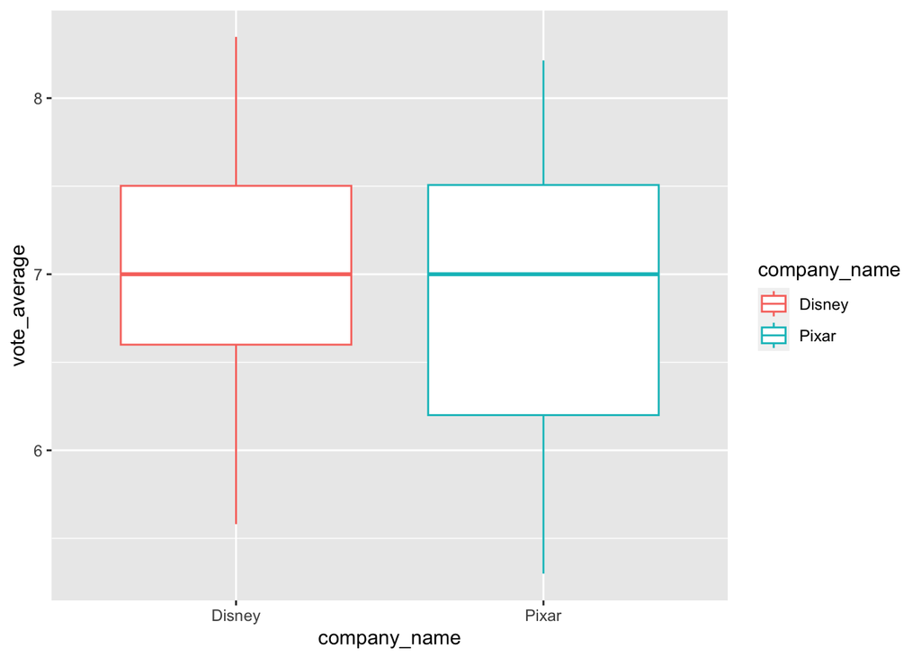

```r
 # Part 4

Disney<- str_glue("https://api.themoviedb.org/3/",
                  "search/company",
                  "?api_key=55b3238346b11e88d118b5a647963747",
                  "&query=Disney&page=1") %>%
  GET() %>%
  content() %>%
  pluck("results") %>%
  map_df(magrittr::extract, c("name", "id"))

Disney_id_table<-Disney%>%
  kable()

Disney_movies<- str_glue("https://api.themoviedb.org/3/",
                         "discover/movie",
                         "?api_key=55b3238346b11e88d118b5a647963747",
                         "&include_adult=false&include_video=false&page={pages}&primary_release_year=>%3D2006&with_companies=2") %>%
  map(GET) %>%
  map(content)%>%
  map(pluck, "results") %>%
  flatten() %>%
  map_df(magrittr::extract, c("original_title","release_date","vote_average", "vote_count","popularity"))

Disney_movie_table<-Disney_movies %>%
  kable()

Pixar_movies <- str_glue(
  "https://api.themoviedb.org/3/",
  "discover/movie",
  "?api_key=55b3238346b11e88d118b5a647963747",
  "&include_adult=false&include_video=false&page={pages}&primary_release_year=>%3D2006&with_companies=3"
) %>%
  map(GET) %>%
  map(content) %>%
  map(pluck, "results") %>%
  flatten() %>%
  map_df(
    magrittr::extract,
    c("original_title","release_date", "vote_average","vote_count","popularity")
  )

Pixar_movie_table<-Pixar_movies %>%
  kable()

Pixar_filtered<-Pixar_movies %>%
                mutate(company_name="Pixar") %>%
                filter(vote_count>=50)
Disney_filtered<-Disney_movies %>%
                mutate(company_name="Disney") %>%
                filter(vote_count>=50)
Disney_Pixar<-bind_rows(Pixar_filtered,Disney_filtered)


Disney_Pixar %>%
  select(vote_average,popularity,company_name) %>%
  ggplot2::ggplot(mapping = aes(x = company_name, y = vote_average, group=company_name)) +
  geom_boxplot(aes(colour=company_name))
```

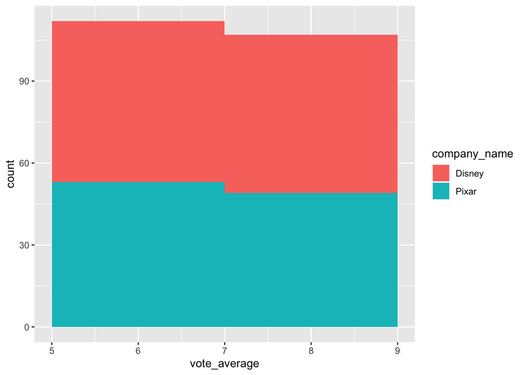

```r
Disney_Pixar %>%
  select(vote_average,popularity,company_name) %>%
  ggplot(mapping = aes(x = vote_average, fill = company_name)) +
  geom_histogram(binwidth = 2)
```

```r
Disney_Pixar %>%
  select(vote_average,popularity,company_name) %>%
  infer::t_test(vote_average ~ company_name,
         order = c("Pixar", "Disney")
         ,var.equal = FALSE)
```

```
## # A tibble: 1 × 7
##   statistic  t_df p_value alternative estimate lower_ci upper_ci
##       <dbl> <dbl>   <dbl> <chr>          <dbl>    <dbl>    <dbl>
## 1     -1.35  198.   0.178 two.sided     -0.124   -0.305   0.0569
```

Searching for Disney id :

| name | id |
| --- | --- |
| Disney Destinations | 104966 |
| Walt Disney Productions | 3166 |
| DisneyToon Studios | 5391 |
| Walt Disney Imagineering | 15935 |
| The Walt Disney Company Italia | 81026 |
| Walt Disney Home Video | 126540 |
| Walt Disney Animation Japan | 40148 |
| Walt Disney Feature Animation | 171656 |
| Walt Disney Studio | 171657 |
| The Walt Disney Company CIS | 101999 |
| Walt Disney Studios | 109755 |
| Walt Disney Animation | 112779 |
| Walt Disney World Resorts | 158079 |
| Walt Disney Animation Studios | 158526 |
| Walt Disney Germany | 88716 |
| Disney Digital Network | 91233 |
| The Walt Disney Company France | 135745 |
| Disney Media Productions | 52126 |
| Disney Theatrical Group | 107038 |
| Disney Broadcast Production | 107039 |

Disney id (Walt Disney Pictures) was found to be 2.

vote averages and vote counts for Disney movies :

| original_title | release_date | vote_average | vote_count | popularity |
| --- | --- | --- | --- | --- |
| Wish | 2023-11-13 | 6.670 | 653 | 990.424 |
| Elemental | 2023-06-14 | 7.678 | 3633 | 226.540 |
| Pirates of the Caribbean: Dead Man’s Chest | 2006-07-06 | 7.300 | 15190 | 195.735 |
| Turning Red | 2022-03-10 | 7.400 | 4726 | 149.090 |
| Inside Out 2 | 2024-06-13 | 0.000 | 0 | 139.944 |
| The Little Mermaid | 2023-05-18 | 6.400 | 2582 | 124.647 |
| Encanto | 2021-10-13 | 7.611 | 8969 | 124.617 |
| Us Again | 2021-03-05 | 7.855 | 294 | 123.568 |
| The Chronicles of Narnia: The Lion, the Witch and the Wardrobe | 2005-12-07 | 7.132 | 10115 | 122.772 |
| Inside Out | 2015-06-09 | 7.900 | 19982 | 120.070 |
| Pirates of the Caribbean: The Curse of the Black Pearl | 2003-07-09 | 7.800 | 19667 | 111.142 |
| Pirates of the Caribbean: At World’s End | 2007-05-19 | 7.200 | 13643 | 109.935 |
| Pirates of the Caribbean: On Stranger Tides | 2011-05-15 | 6.500 | 13397 | 106.575 |
| Zootopia | 2016-02-11 | 7.748 | 15577 | 102.959 |
| Coco | 2017-10-27 | 8.214 | 18491 | 99.897 |
| Soul | 2020-12-25 | 8.140 | 9833 | 98.039 |
| Cars 2 | 2011-06-11 | 6.094 | 7327 | 96.735 |
| Big Hero 6 | 2014-10-24 | 7.735 | 15010 | 89.478 |
| The Lion King | 1994-06-24 | 8.257 | 17412 | 87.355 |
| Frozen | 2013-11-20 | 7.245 | 15862 | 85.265 |
| Frozen II | 2019-11-20 | 7.261 | 9295 | 85.032 |
| Tangled | 2010-11-24 | 7.604 | 10837 | 84.194 |
| Ratatouille | 2007-06-28 | 7.815 | 16142 | 83.446 |
| Cinderella | 2015-03-06 | 6.807 | 6816 | 81.538 |
| Beauty and the Beast | 2017-03-16 | 6.967 | 15049 | 79.999 |
| Mulan | 1998-06-18 | 7.900 | 9155 | 77.714 |
| The Lion King | 2019-07-12 | 7.100 | 9528 | 77.515 |
| Luca | 2021-06-17 | 7.845 | 7884 | 76.823 |
| Tarzan | 1999-06-18 | 7.404 | 6403 | 74.106 |
| Beauty and the Beast | 1991-10-22 | 7.735 | 9477 | 73.333 |

[output cut: 90 more lines]

vote averages and vote counts for Pixar movies :

| original_title | release_date | vote_average | vote_count | popularity |
| --- | --- | --- | --- | --- |
| Elemental | 2023-06-14 | 7.678 | 3633 | 226.540 |
| Turning Red | 2022-03-10 | 7.400 | 4726 | 149.090 |
| Inside Out 2 | 2024-06-13 | 0.000 | 0 | 139.944 |
| Inside Out | 2015-06-09 | 7.900 | 19982 | 120.070 |
| Monsters, Inc. | 2001-11-01 | 7.841 | 17607 | 105.201 |
| Toy Story | 1995-10-30 | 7.972 | 17572 | 101.063 |
| Coco | 2017-10-27 | 8.214 | 18491 | 99.897 |
| Soul | 2020-12-25 | 8.140 | 9833 | 98.039 |
| Cars 2 | 2011-06-11 | 6.094 | 7327 | 96.735 |
| Loop | 2019-01-10 | 6.737 | 173 | 90.088 |
| Finding Nemo | 2003-05-30 | 7.824 | 18431 | 89.958 |
| Carl’s Date | 2023-06-15 | 7.523 | 351 | 84.795 |
| Toy Story 2 | 1999-10-30 | 7.591 | 13200 | 83.984 |
| Ratatouille | 2007-06-28 | 7.815 | 16142 | 83.446 |
| Up | 2009-05-28 | 7.954 | 19308 | 82.419 |
| Luca | 2021-06-17 | 7.845 | 7884 | 76.823 |
| Toy Story 4 | 2019-06-19 | 7.509 | 9291 | 71.802 |
| Cars 3 | 2017-06-15 | 6.851 | 5427 | 70.624 |
| A Bug’s Life | 1998-11-25 | 6.969 | 8723 | 68.054 |
| Kitbull | 2019-01-18 | 7.953 | 341 | 65.639 |
| WALL·E | 2008-06-22 | 8.100 | 17872 | 60.833 |
| The Incredibles | 2004-10-27 | 7.703 | 16924 | 59.800 |
| Toy Story 3 | 2010-06-16 | 7.794 | 14051 | 59.068 |
| Brave | 2012-06-21 | 7.016 | 12841 | 58.819 |
| Incredibles 2 | 2018-06-14 | 7.474 | 12298 | 56.880 |
| Monsters University | 2013-06-19 | 7.000 | 10116 | 55.397 |
| Lightyear | 2022-06-15 | 7.012 | 3207 | 53.061 |
| Cars | 2006-06-08 | 6.951 | 13229 | 50.313 |
| The Good Dinosaur | 2015-11-14 | 6.740 | 5262 | 48.127 |
| Finding Dory | 2016-06-16 | 7.000 | 11615 | 40.076 |

[output cut: 90 more lines]

Using the box plot, it looks **vote_average** is comparable for this set of movies (from year 2006) from Pixar and Disney.

Here p-value is greater than 0.05 which means there is not a strong relationship between the variables **vote_average** and **company_name** of movies (from year 2006) from Pixar and Disney.